# Lab3_Assignment

## **Lab 3: Neural Networks**

#### **Objective:**

- To reproduce and extend the workflow for the circles_binary_classification.csv dataset

##### *Submitted By: Sulav Karki (ACE079BCT070)*

#### **Theory:**

Neural Networks are a class of models loosely based on the human brain's neurons thus the name Neural Network. The NN is a model capable of approximating complex non-linear relationships between inputs (features) and the outputs. The output of a neuron(Y) is given by: $$ Y = f(w_1 \cdot X_1 + w_2 \cdot X_2 + b) $$

```python
import torch
from torch import nn
import pandas as pd
import numpy as np
import matplotlib.pyplot as plt
from sklearn.model_selection import train_test_split
from sklearn.datasets import make_circles
```

```python
torch.manual_seed(42)
np.random.seed(42)
```

```python
def plot_decision_boundary(model: torch.nn.Module, X: torch.Tensor, y: torch.Tensor):
    model.to("cpu")
    X, y = X.to("cpu"), y.to("cpu")

    # Setup meshgrid
    x_min, x_max = X[:, 0].min() - 0.1, X[:, 0].max() + 0.1
    y_min, y_max = X[:, 1].min() - 0.1, X[:, 1].max() + 0.1
    xx, yy = np.meshgrid(np.linspace(x_min, x_max, 101),
                         np.linspace(y_min, y_max, 101))

    # Make features
    X_to_pred_on = torch.from_numpy(np.column_stack((xx.ravel(), yy.ravel()))).float()

    # Make predictions
    model.eval()
    with torch.inference_mode():
        y_logits = model(X_to_pred_on)

    # Test for multi-class or binary and adjust predictions
    if len(torch.unique(y)) > 2:
        y_pred = torch.softmax(y_logits, dim=1).argmax(dim=1)  # mutli-class
    else:
        y_pred = torch.round(torch.sigmoid(y_logits))  # binary

    y_pred = y_pred.reshape(xx.shape).detach().numpy()
    plt.contourf(xx, yy, y_pred, cmap=plt.cm.RdYlBu, alpha=0.7)
    plt.scatter(X[:, 0], X[:, 1], c=y, s=40, cmap=plt.cm.RdYlBu)
    plt.xlim(xx.min(), xx.max())
    plt.ylim(yy.min(), yy.max())

def plot_loss_curves(train_losses, test_losses):
    plt.figure(figsize=(8, 5))
    plt.plot(range(len(train_losses)), train_losses, label="Train Loss")
    plt.plot(range(len(test_losses)), test_losses, label="Test Loss")
    plt.title("Loss Curves")
    plt.xlabel("Epochs")
    plt.ylabel("Loss")
    plt.legend()
    plt.show()
```

### 1. DATA RETRIEVAL & INSPECTION

```python
filename = 'circles_binary_classification.csv'
data = pd.read_csv(filename)

print(data.head())
```

```
         X1        X2  label
0  0.754246  0.231481      1
1 -0.756159  0.153259      1
2 -0.815392  0.173282      1
3 -0.393731  0.692883      1
4  0.442208 -0.896723      0
```

### 2. DATA CLEANING & FEATURE DESIGN

```python
print(data.describe())

# Check for NaN
if data.isnull().values.any():
    print("Data contains NaNs, dropping...")
    data = data.dropna()

# Create X and y
X_input = data[['X1', 'X2']].values
y_input = data['label'].values

# Turn data into tensors
X = torch.from_numpy(X_input).type(torch.float)
y = torch.from_numpy(y_input).type(torch.float)

print(f"\nTensor shapes: X: {X.shape}, y: {y.shape}")
```

```
                X1           X2       label
count  1000.000000  1000.000000  1000.00000
mean     -0.000448    -0.000804     0.50000
std       0.639837     0.641156     0.50025
min      -1.059502    -1.067768     0.00000
25%      -0.619251    -0.612176     0.00000
50%       0.008762    -0.003949     0.50000
75%       0.621933     0.624822     1.00000
max       1.033712     1.036004     1.00000

Tensor shapes: X: torch.Size([1000, 2]), y: torch.Size([1000])
```

### 3. VISUALIZE DATA

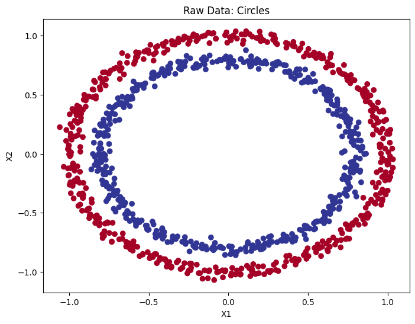

```python
plt.figure(figsize=(8, 6))
plt.scatter(x=data['X1'], y=data['X2'], c=data['label'], cmap=plt.cm.RdYlBu)
plt.title("Raw Data: Circles")
plt.xlabel("X1")
plt.ylabel("X2")
plt.show()
```

### 4. TRAIN/TEST SPLIT

```python
X_train, X_test, y_train, y_test = train_test_split(
    X, y, test_size=0.2, random_state=42
)
print(f"Train size: {len(X_train)}, Test size: {len(X_test)}")
```

```
Train size: 800, Test size: 200
```

### 5. DEVICE & DTYPE

```python
device = "cuda" if torch.cuda.is_available() else "cpu"
print(f"Using device: {device}")

# Move data to device
X_train, y_train = X_train.to(device), y_train.to(device)
X_test, y_test = X_test.to(device), y_test.to(device)
```

```
Using device: cpu
```

#### Setup Training

```python
def accuracy_fn(y_true, y_pred):
    correct = torch.eq(y_true, y_pred).sum().item()
    acc = (correct / len(y_pred)) * 100
    return acc

def train_and_test_loop(model, epochs, loss_fn, optimizer, name="Model"):
    print(f"\nTraining {name} for {epochs} epochs...")
    train_losses, test_losses = [], []
    model.to(device)

    for epoch in range(epochs):
        ### Training
        model.train()
        y_logits = model(X_train).squeeze()
        y_pred = torch.round(torch.sigmoid(y_logits))
        loss = loss_fn(y_logits, y_train)
        acc = accuracy_fn(y_true=y_train, y_pred=y_pred)
        optimizer.zero_grad()
        loss.backward()
        optimizer.step()

        ### Testing
        model.eval()
        with torch.inference_mode():
            test_logits = model(X_test).squeeze()
            test_pred = torch.round(torch.sigmoid(test_logits))
            test_loss = loss_fn(test_logits, y_test)
            test_acc = accuracy_fn(y_true=y_test, y_pred=test_pred)

        train_losses.append(loss.item())
        test_losses.append(test_loss.item())

        if epoch % (epochs // 10) == 0:
            print(f"Epoch: {epoch} | Loss: {loss:.5f}, Acc: {acc:.2f}% | Test Loss: {test_loss:.5f}, Test Acc: {test_acc:.2f}%")

    return train_losses, test_losses
```

### 6. Implement baseline models

#### ModelV0:: 2 -> 5 -> 1 (No Activation)

```
Training ModelV0 for 100 epochs...
Epoch: 0 | Loss: 0.69569, Acc: 50.00% | Test Loss: 0.69721, Test Acc: 50.00%
Epoch: 10 | Loss: 0.69403, Acc: 50.00% | Test Loss: 0.69615, Test Acc: 50.00%
Epoch: 20 | Loss: 0.69343, Acc: 46.00% | Test Loss: 0.69585, Test Acc: 48.50%
Epoch: 30 | Loss: 0.69321, Acc: 49.00% | Test Loss: 0.69577, Test Acc: 47.50%
Epoch: 40 | Loss: 0.69312, Acc: 49.50% | Test Loss: 0.69573, Test Acc: 46.50%
Epoch: 50 | Loss: 0.69308, Acc: 50.38% | Test Loss: 0.69569, Test Acc: 46.50%
Epoch: 60 | Loss: 0.69306, Acc: 50.50% | Test Loss: 0.69564, Test Acc: 46.50%
Epoch: 70 | Loss: 0.69305, Acc: 50.50% | Test Loss: 0.69559, Test Acc: 46.50%
Epoch: 80 | Loss: 0.69304, Acc: 50.75% | Test Loss: 0.69553, Test Acc: 46.50%
Epoch: 90 | Loss: 0.69303, Acc: 50.38% | Test Loss: 0.69547, Test Acc: 46.50%
```

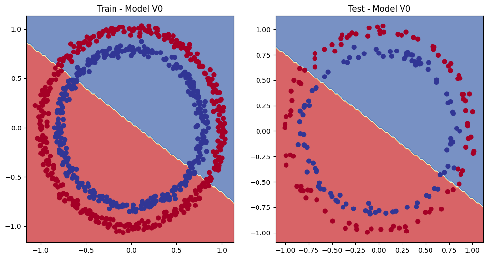

```python
class ModelV0(nn.Module):
    def __init__(self):
        super().__init__()
        self.layer_1 = nn.Linear(in_features=2, out_features=5)
        self.layer_2 = nn.Linear(in_features=5, out_features=1)

    def forward(self, x):
        return self.layer_2(self.layer_1(x))

model_0 = ModelV0().to(device)

# Optimizer & Loss
loss_fn = nn.BCEWithLogitsLoss()
optimizer_0 = torch.optim.SGD(params=model_0.parameters(), lr=0.1)

# Train
train_loss_0, test_loss_0 = train_and_test_loop(
    model_0, 100, loss_fn, optimizer_0, "ModelV0"
)

# Plot Results
plt.figure(figsize=(12, 6))
plt.subplot(1, 2, 1)
plt.title("Train - Model V0")
plot_decision_boundary(model_0, X_train, y_train)
plt.subplot(1, 2, 2)
plt.title("Test - Model V0")
plot_decision_boundary(model_0, X_test, y_test)
plt.show()
```

#### ModelV1: 2 -> 15 -> 15 -> 1 (No Activation)

```
Training ModelV1 for 1000 epochs...
Epoch: 0 | Loss: 0.69423, Acc: 50.25% | Test Loss: 0.69366, Test Acc: 56.50%
Epoch: 100 | Loss: 0.69302, Acc: 51.12% | Test Loss: 0.69415, Test Acc: 46.50%
Epoch: 200 | Loss: 0.69298, Acc: 51.25% | Test Loss: 0.69456, Test Acc: 46.00%
Epoch: 300 | Loss: 0.69298, Acc: 51.50% | Test Loss: 0.69465, Test Acc: 45.00%
Epoch: 400 | Loss: 0.69298, Acc: 51.12% | Test Loss: 0.69467, Test Acc: 46.00%
Epoch: 500 | Loss: 0.69298, Acc: 51.00% | Test Loss: 0.69468, Test Acc: 46.00%
Epoch: 600 | Loss: 0.69298, Acc: 51.00% | Test Loss: 0.69468, Test Acc: 46.00%
Epoch: 700 | Loss: 0.69298, Acc: 51.00% | Test Loss: 0.69468, Test Acc: 46.00%
Epoch: 800 | Loss: 0.69298, Acc: 51.00% | Test Loss: 0.69468, Test Acc: 46.00%
Epoch: 900 | Loss: 0.69298, Acc: 51.00% | Test Loss: 0.69468, Test Acc: 46.00%
```

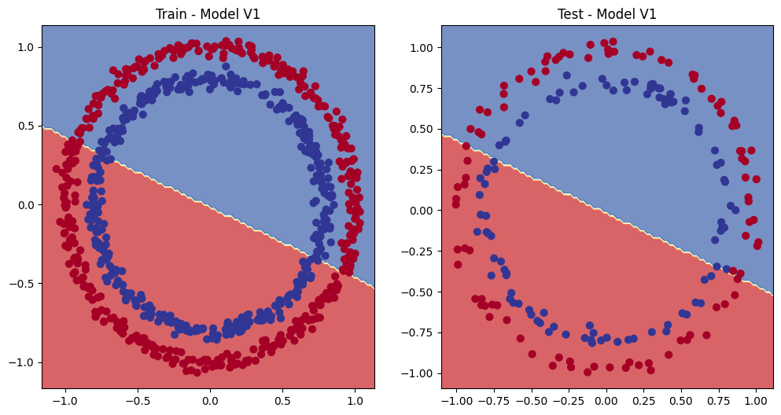

```python
class ModelV1(nn.Module):
    def __init__(self):
        super().__init__()
        self.layer_1 = nn.Linear(in_features=2, out_features=15)
        self.layer_2 = nn.Linear(in_features=15, out_features=15)
        self.layer_3 = nn.Linear(in_features=15, out_features=1)

    def forward(self, x):
        return self.layer_3(self.layer_2(self.layer_1(x)))

model_1 = ModelV1().to(device)
optimizer_1 = torch.optim.SGD(params=model_1.parameters(), lr=0.1)

# Train
train_loss_1, test_loss_1 = train_and_test_loop(
    model_1, 1000, loss_fn, optimizer_1, "ModelV1"
)

# Plot Results
plt.figure(figsize=(12, 6))
plt.subplot(1, 2, 1)
plt.title("Train - Model V1")
plot_decision_boundary(model_1, X_train, y_train)
plt.subplot(1, 2, 2)
plt.title("Test - Model V1")
plot_decision_boundary(model_1, X_test, y_test)
plt.show()
```

#### ModelV2: 2 -> 64 -> 64 -> 10 -> 1 ( With ReLU Activation)

```
Training ModelV2 for 1500 epochs...
Epoch: 0 | Loss: 0.69509, Acc: 50.00% | Test Loss: 0.69436, Test Acc: 50.00%
Epoch: 150 | Loss: 0.68231, Acc: 59.00% | Test Loss: 0.68450, Test Acc: 59.50%
Epoch: 300 | Loss: 0.64169, Acc: 87.12% | Test Loss: 0.65048, Test Acc: 86.00%
Epoch: 450 | Loss: 0.44545, Acc: 92.12% | Test Loss: 0.50807, Test Acc: 57.50%
Epoch: 600 | Loss: 0.21545, Acc: 98.25% | Test Loss: 0.23260, Test Acc: 92.50%
Epoch: 750 | Loss: 0.05439, Acc: 100.00% | Test Loss: 0.07262, Test Acc: 100.00%
Epoch: 900 | Loss: 0.02572, Acc: 100.00% | Test Loss: 0.03995, Test Acc: 100.00%
Epoch: 1050 | Loss: 0.01356, Acc: 100.00% | Test Loss: 0.02542, Test Acc: 100.00%
Epoch: 1200 | Loss: 0.00850, Acc: 100.00% | Test Loss: 0.01856, Test Acc: 100.00%
Epoch: 1350 | Loss: 0.00602, Acc: 100.00% | Test Loss: 0.01487, Test Acc: 100.00%
```

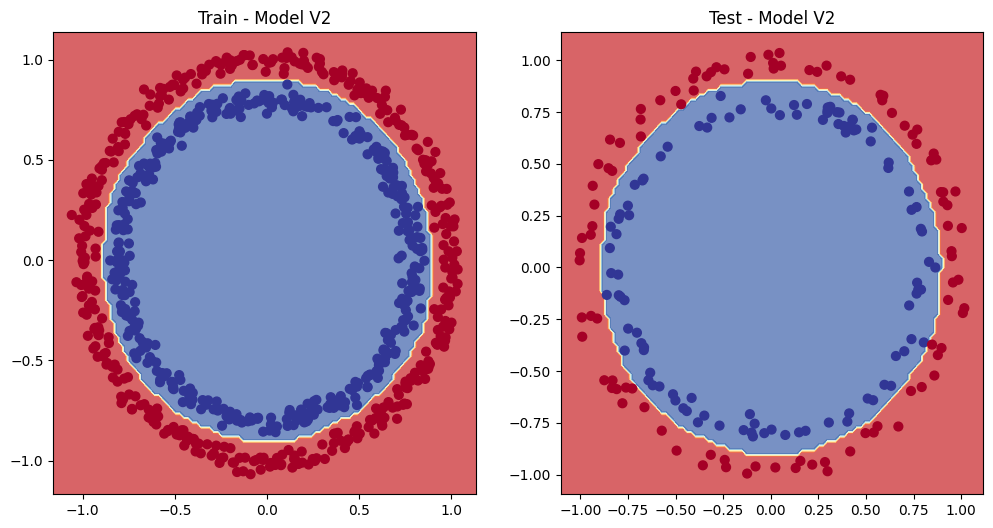

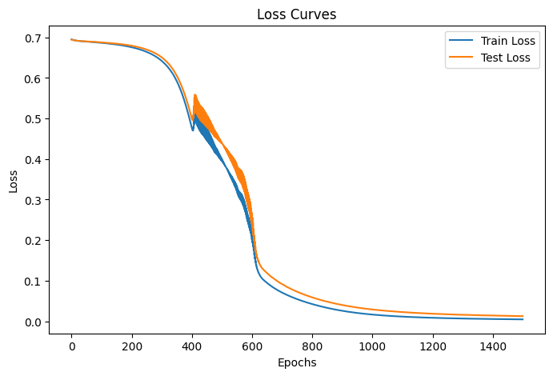

```python
class ModelV2(nn.Module):
    def __init__(self):
        super().__init__()
        self.layer_1 = nn.Linear(in_features=2, out_features=64)
        self.layer_2 = nn.Linear(in_features=64, out_features=64)
        self.layer_3 = nn.Linear(in_features=64, out_features=10)
        self.layer_4 = nn.Linear(in_features=10, out_features=1)
        self.relu = nn.ReLU()

    def forward(self, x):
        x = self.relu(self.layer_1(x))
        x = self.relu(self.layer_2(x))
        x = self.relu(self.layer_3(x))
        return self.layer_4(x)

model_2 = ModelV2().to(device)
optimizer_2 = torch.optim.SGD(params=model_2.parameters(), lr=0.1)

# Train
train_loss_2, test_loss_2 = train_and_test_loop(
    model_2, 1500, loss_fn, optimizer_2, "ModelV2"
)

# Plot Results
plt.figure(figsize=(12, 6))
plt.subplot(1, 2, 1)
plt.title("Train - Model V2")
plot_decision_boundary(model_2, X_train, y_train)
plt.subplot(1, 2, 2)
plt.title("Test - Model V2")
plot_decision_boundary(model_2, X_test, y_test)
plt.show()

# Plot Loss Curves
plot_loss_curves(train_loss_2, test_loss_2)
```

### Discussion

**ModelV0 & ModelV1 (Linear Models)**: Both of these models were achieved at around 50% accuracy despite there different architectures. This was due the fact that they were linear in nature and added layers without any activation function. Due to this they were unable to properly capture the circular pattern.

### Conclusion

As a whole, though this lab we were able to come to the conclusion that actvation functions are of high importance when it comes to Neural Networls inorder to train the NN models so that they may properly learn complex, non-linear patterns.